# TCGA_LUAD

```python
!pip install kaggle
```

```python
! mkdir ~/.kaggle
```

```python
!cp /content/drive/MyDrive/kaggle/kaggle.json ~/.kaggle/kaggle.json
```

```python
!chmod 600 ~/.kaggle/kaggle.json
```

```python
! pip install opendatasets
```

```
Downloading opendatasets-0.1.22-py3-none-any.whl (15 kB)
```

```python
import opendatasets as od
od.download("https://www.kaggle.com/datasets/nahin333/tcgaluad/data")
```

```
Please provide your Kaggle credentials to download this dataset. Learn more: http://bit.ly/kaggle-creds
Your Kaggle username: alina2k
Your Kaggle Key: ··········
Dataset URL: https://www.kaggle.com/datasets/nahin333/tcgaluad
Downloading tcgaluad.zip to ./tcgaluad
```

```python
# Import necessary libraries
import opendatasets as od
import pandas as pd
import numpy as np
import matplotlib.pyplot as plt
import seaborn as sns
from matplotlib import pyplot as plt
```

```python
data = pd.read_csv("/content/tcgaluad/TCGA-LUAD/manifest-1Rd7jPNd5199284876140322680/metadata.csv")
```

```python
data.size
```

```
10608
```

```python
print(data.shape)
```

```
(624, 17)
```

```python
data.info()
```

```
<class 'pandas.core.frame.DataFrame'>
RangeIndex: 624 entries, 0 to 623
Data columns (total 17 columns):
 #   Column                Non-Null Count  Dtype
---  ------                --------------  -----
 0   Series UID            624 non-null    object
 1   Collection            624 non-null    object
 2   3rd Party Analysis    0 non-null      float64
 3   Data Description URI  624 non-null    object
 4   Subject ID            624 non-null    object
 5   Study UID             624 non-null    object
 6   Study Description     264 non-null    object
 7   Study Date            624 non-null    object
 8   Series Description    495 non-null    object
 9   Manufacturer          624 non-null    object
 10  Modality              624 non-null    object
 11  SOP Class Name        624 non-null    object
 12  SOP Class UID         624 non-null    object
 13  Number of Images      624 non-null    int64
 14  File Size             624 non-null    object
 15  File Location         624 non-null    object
 16  Download Timestamp    624 non-null    object
dtypes: float64(1), int64(1), object(15)
memory usage: 83.0+ KB
```

```python
data.head(5)
```

|  | Series UID | Collection | 3rd Party Analysis | Data Description URI | Subject ID | Study UID | Study Description | Study Date | Series Description | Manufacturer | Modality | SOP Class Name | SOP Class UID | Number of Images | File Size | File Location | Download Timestamp |
| --- | --- | --- | --- | --- | --- | --- | --- | --- | --- | --- | --- | --- | --- | --- | --- | --- | --- |
| 0 | 1.3.6.1.4.1.14519.5.2.1.7777.9002.294081805871... | TCGA-LUAD | NaN | https://doi.org/10.7937/K9/TCIA.2016.JGNIHEP5 | TCGA-17-Z011 | 1.3.6.1.4.1.14519.5.2.1.7777.9002.119175415668... | NaN | 09-05-1982 | Topogram | SIEMENS | CT | CT Image Storage | 1.2.840.10008.5.1.4.1.1.2 | 1 | 515.28 KB | .\TCGA-LUAD\TCGA-17-Z011\09-05-1982-68452\1.00... | 2021-07-27T20:15:50.078 |
| 1 | 1.3.6.1.4.1.14519.5.2.1.7777.9002.927019691832... | TCGA-LUAD | NaN | https://doi.org/10.7937/K9/TCIA.2016.JGNIHEP5 | TCGA-17-Z011 | 1.3.6.1.4.1.14519.5.2.1.7777.9002.119175415668... | NaN | 09-05-1982 | Chest Routine 1 | SIEMENS | CT | CT Image Storage | 1.2.840.10008.5.1.4.1.1.2 | 71 | 35.73 MB | .\TCGA-LUAD\TCGA-17-Z011\09-05-1982-68452\2.00... | 2021-07-27T20:19:47.515 |
| 2 | 1.3.6.1.4.1.14519.5.2.1.7777.9002.235710448471... | TCGA-LUAD | NaN | https://doi.org/10.7937/K9/TCIA.2016.JGNIHEP5 | TCGA-17-Z011 | 1.3.6.1.4.1.14519.5.2.1.7777.9002.123752081377... | NaN | 10-16-1982 | NaN | SIEMENS | CT | CT Image Storage | 1.2.840.10008.5.1.4.1.1.2 | 1 | 515.73 KB | .\TCGA-LUAD\TCGA-17-Z011\10-16-1982-21430\2.00... | 2021-07-27T20:19:58.242 |
| 3 | 1.3.6.1.4.1.14519.5.2.1.7777.9002.206144478142... | TCGA-LUAD | NaN | https://doi.org/10.7937/K9/TCIA.2016.JGNIHEP5 | TCGA-17-Z011 | 1.3.6.1.4.1.14519.5.2.1.7777.9002.123752081377... | NaN | 10-16-1982 | NaN | SIEMENS | CT | CT Image Storage | 1.2.840.10008.5.1.4.1.1.2 | 34 | 17.12 MB | .\TCGA-LUAD\TCGA-17-Z011\10-16-1982-21430\3.00... | 2021-07-27T20:24:00.404 |
| 4 | 1.3.6.1.4.1.14519.5.2.1.7777.9002.152508401007... | TCGA-LUAD | NaN | https://doi.org/10.7937/K9/TCIA.2016.JGNIHEP5 | TCGA-17-Z011 | 1.3.6.1.4.1.14519.5.2.1.7777.9002.233484322163... | NaN | 09-05-1982 | Topogram | SIEMENS | CT | CT Image Storage | 1.2.840.10008.5.1.4.1.1.2 | 1 | 515.28 KB | .\TCGA-LUAD\TCGA-17-Z011\09-05-1982-03157\1.00... | 2021-07-27T20:24:05.753 |

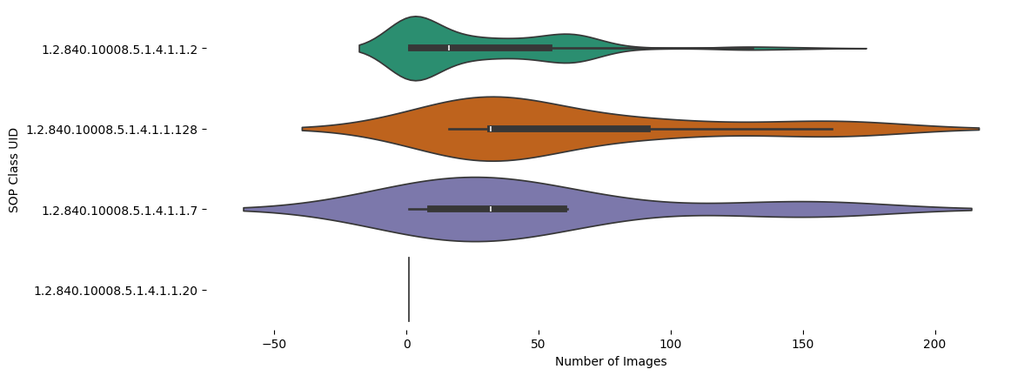

```python
# @title SOP Class UID vs Number of Images

from matplotlib import pyplot as plt
import seaborn as sns
figsize = (12, 1.2 * len(data['SOP Class UID'].unique()))
plt.figure(figsize=figsize)
sns.violinplot(data, x='Number of Images', y='SOP Class UID', inner='box', palette='Dark2')
sns.despine(top=True, right=True, bottom=True, left=True)
```

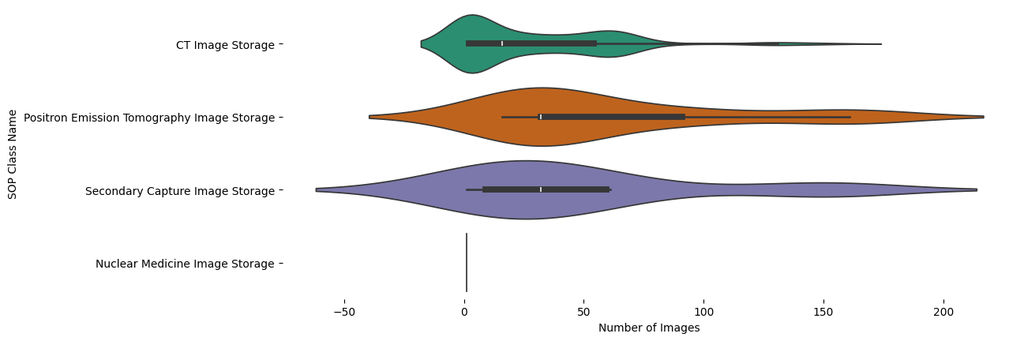

```python
# @title SOP Class Name vs Number of Images

from matplotlib import pyplot as plt
import seaborn as sns
figsize = (12, 1.2 * len(data['SOP Class Name'].unique()))
plt.figure(figsize=figsize)
sns.violinplot(data, x='Number of Images', y='SOP Class Name', inner='box', palette='Dark2')
sns.despine(top=True, right=True, bottom=True, left=True)
```

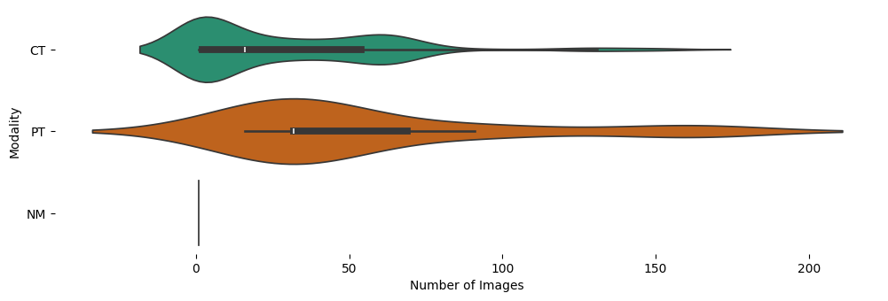

```python
# @title Modality vs Number of Images

from matplotlib import pyplot as plt
import seaborn as sns
figsize = (12, 1.2 * len(data['Modality'].unique()))
plt.figure(figsize=figsize)
sns.violinplot(data, x='Number of Images', y='Modality', inner='box', palette='Dark2')
sns.despine(top=True, right=True, bottom=True, left=True)
```

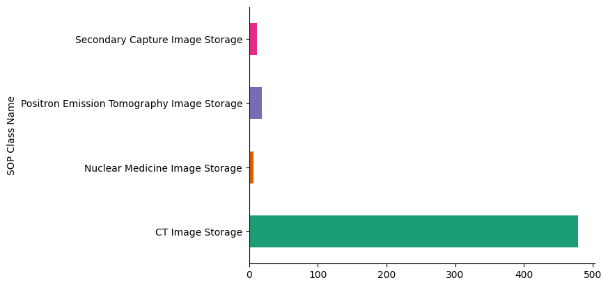

```python
# @title SOP Class Name

from matplotlib import pyplot as plt
import seaborn as sns
data.groupby('SOP Class Name').size().plot(kind='barh', color=sns.palettes.mpl_palette('Dark2'))
plt.gca().spines[['top', 'right',]].set_visible(False)
```

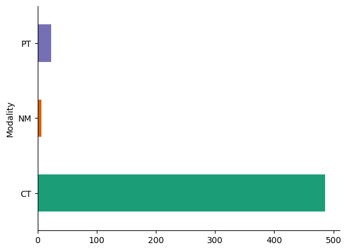

```python
# @title Modality

from matplotlib import pyplot as plt
import seaborn as sns
data.groupby('Modality').size().plot(kind='barh', color=sns.palettes.mpl_palette('Dark2'))
plt.gca().spines[['top', 'right',]].set_visible(False)
```

```python
data.head(5)
```

|  | Series UID | Collection | 3rd Party Analysis | Data Description URI | Subject ID | Study UID | Study Description | Study Date | Series Description | Manufacturer | Modality | SOP Class Name | SOP Class UID | Number of Images | File Size | File Location | Download Timestamp |
| --- | --- | --- | --- | --- | --- | --- | --- | --- | --- | --- | --- | --- | --- | --- | --- | --- | --- |
| 0 | 1.3.6.1.4.1.14519.5.2.1.7777.9002.294081805871... | TCGA-LUAD | NaN | https://doi.org/10.7937/K9/TCIA.2016.JGNIHEP5 | TCGA-17-Z011 | 1.3.6.1.4.1.14519.5.2.1.7777.9002.119175415668... | NaN | 09-05-1982 | Topogram | SIEMENS | CT | CT Image Storage | 1.2.840.10008.5.1.4.1.1.2 | 1 | 515.28 KB | .\TCGA-LUAD\TCGA-17-Z011\09-05-1982-68452\1.00... | 2021-07-27T20:15:50.078 |
| 1 | 1.3.6.1.4.1.14519.5.2.1.7777.9002.927019691832... | TCGA-LUAD | NaN | https://doi.org/10.7937/K9/TCIA.2016.JGNIHEP5 | TCGA-17-Z011 | 1.3.6.1.4.1.14519.5.2.1.7777.9002.119175415668... | NaN | 09-05-1982 | Chest Routine 1 | SIEMENS | CT | CT Image Storage | 1.2.840.10008.5.1.4.1.1.2 | 71 | 35.73 MB | .\TCGA-LUAD\TCGA-17-Z011\09-05-1982-68452\2.00... | 2021-07-27T20:19:47.515 |
| 2 | 1.3.6.1.4.1.14519.5.2.1.7777.9002.235710448471... | TCGA-LUAD | NaN | https://doi.org/10.7937/K9/TCIA.2016.JGNIHEP5 | TCGA-17-Z011 | 1.3.6.1.4.1.14519.5.2.1.7777.9002.123752081377... | NaN | 10-16-1982 | NaN | SIEMENS | CT | CT Image Storage | 1.2.840.10008.5.1.4.1.1.2 | 1 | 515.73 KB | .\TCGA-LUAD\TCGA-17-Z011\10-16-1982-21430\2.00... | 2021-07-27T20:19:58.242 |
| 3 | 1.3.6.1.4.1.14519.5.2.1.7777.9002.206144478142... | TCGA-LUAD | NaN | https://doi.org/10.7937/K9/TCIA.2016.JGNIHEP5 | TCGA-17-Z011 | 1.3.6.1.4.1.14519.5.2.1.7777.9002.123752081377... | NaN | 10-16-1982 | NaN | SIEMENS | CT | CT Image Storage | 1.2.840.10008.5.1.4.1.1.2 | 34 | 17.12 MB | .\TCGA-LUAD\TCGA-17-Z011\10-16-1982-21430\3.00... | 2021-07-27T20:24:00.404 |
| 4 | 1.3.6.1.4.1.14519.5.2.1.7777.9002.152508401007... | TCGA-LUAD | NaN | https://doi.org/10.7937/K9/TCIA.2016.JGNIHEP5 | TCGA-17-Z011 | 1.3.6.1.4.1.14519.5.2.1.7777.9002.233484322163... | NaN | 09-05-1982 | Topogram | SIEMENS | CT | CT Image Storage | 1.2.840.10008.5.1.4.1.1.2 | 1 | 515.28 KB | .\TCGA-LUAD\TCGA-17-Z011\09-05-1982-03157\1.00... | 2021-07-27T20:24:05.753 |

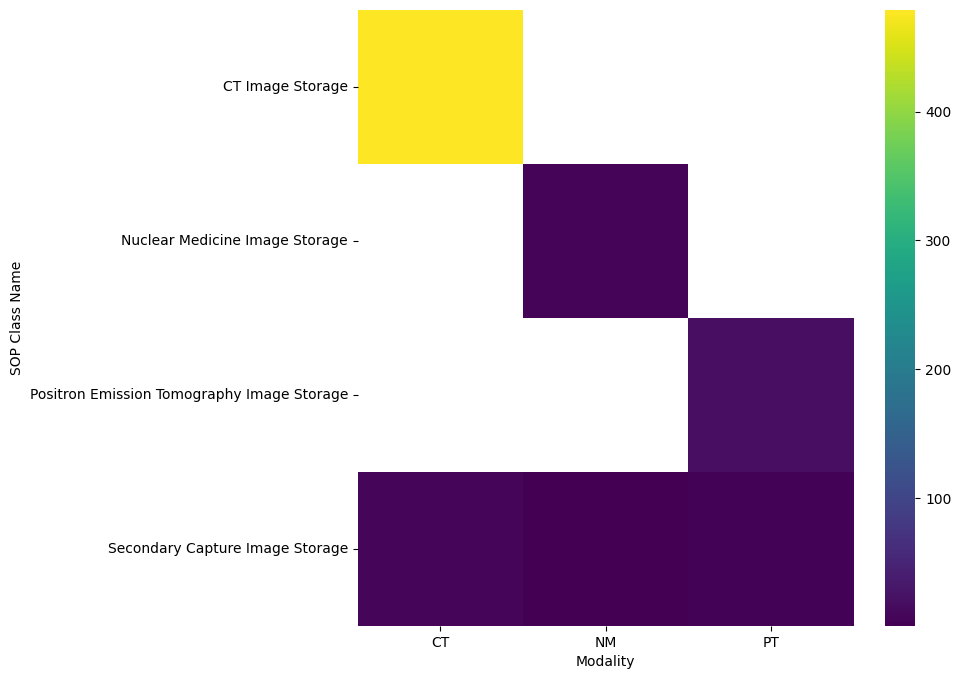

```python
# @title Modality vs SOP Class Name

from matplotlib import pyplot as plt
import seaborn as sns
import pandas as pd
plt.subplots(figsize=(8, 8))
df_2dhist = pd.DataFrame({
    x_label: grp['SOP Class Name'].value_counts()
    for x_label, grp in data.groupby('Modality')
})
sns.heatmap(df_2dhist, cmap='viridis')
plt.xlabel('Modality')
_ = plt.ylabel('SOP Class Name')
```

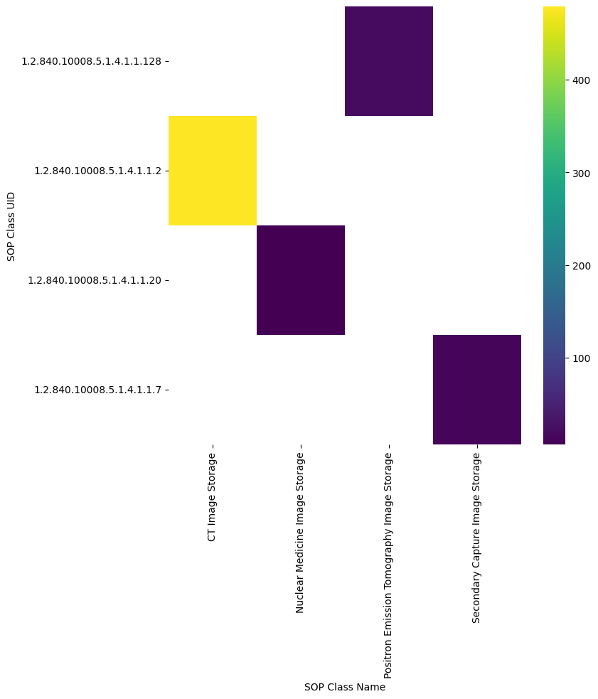

```python
# @title SOP Class Name vs SOP Class UID

from matplotlib import pyplot as plt
import seaborn as sns
import pandas as pd
plt.subplots(figsize=(8, 8))
df_2dhist = pd.DataFrame({
    x_label: grp['SOP Class UID'].value_counts()
    for x_label, grp in data.groupby('SOP Class Name')
})
sns.heatmap(df_2dhist, cmap='viridis')
plt.xlabel('SOP Class Name')
_ = plt.ylabel('SOP Class UID')
```

[output not shown]

Distributions

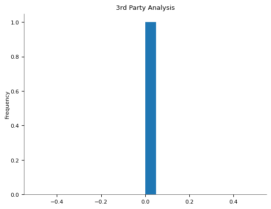

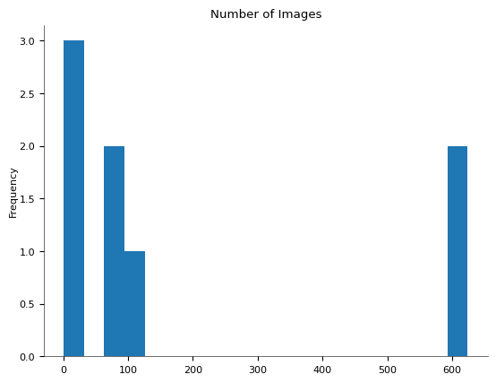

2-d distributions

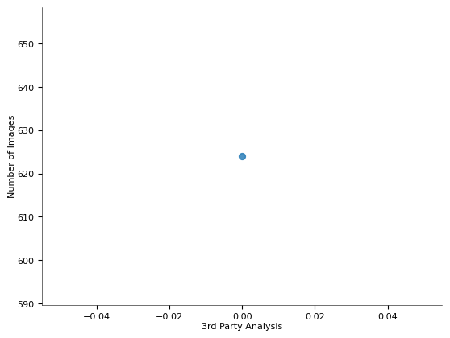

Values

[figure not shown]

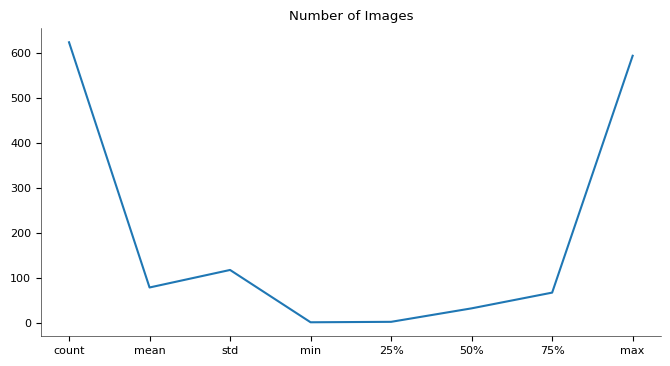

```python
data.describe()
```

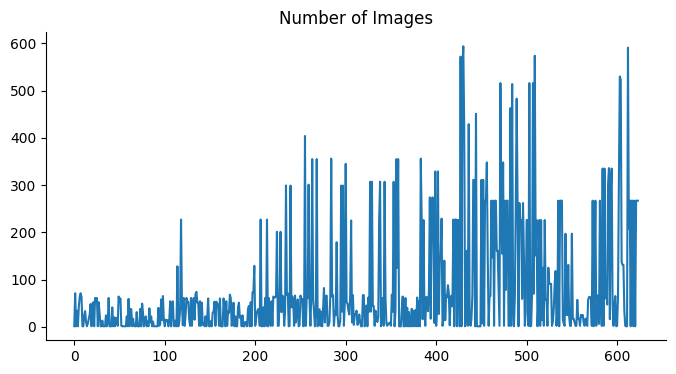

```python
# @title Number of Images

from matplotlib import pyplot as plt
data['Number of Images'].plot(kind='line', figsize=(8, 4), title='Number of Images')
plt.gca().spines[['top', 'right']].set_visible(False)
```

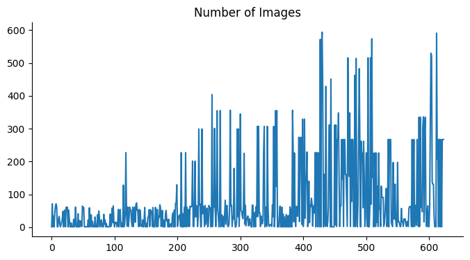

```python
# @title Number of Images

# Assuming you want to create a DataFrame with the 'Number of Images' column
df_number_of_images = pd.DataFrame({'Number of Images': data['Number of Images']})

# Now you can use df_number_of_images for further analysis or visualization

df_number_of_images['Number of Images'].plot(kind='line', figsize=(8, 4), title='Number of Images')
plt.gca().spines[['top', 'right']].set_visible(False)
```

```python
# prompt: Perform Data Cleaning Process on this

# Check for missing values
missing_values = data.isnull().sum()
print("Missing values:\n", missing_values)
```

[output not shown]

```python
# Handle missing values (e.g., fill with mean, median, or drop rows/columns)
# Example: Fill missing values in 'Number of Images' with the mean
data['Number of Images'].fillna(data['Number of Images'].mean(), inplace=True)

# Check for duplicate rows
duplicate_rows = data.duplicated().sum()
print("Duplicate rows:", duplicate_rows)
```

```
Duplicate rows: 0
```

```python
# Remove duplicate rows if necessary
data.drop_duplicates(inplace=True)

# Check for inconsistent data types
print("Data types:\n", data.dtypes)

# Convert data types if necessary
# Example: Convert 'Number of Images' to integer
# data['Number of Images'] = data['Number of Images'].astype(int)

# Identify and handle outliers (e.g., using IQR or z-score)
# Example: Remove outliers in 'Number of Images' using IQR
Q1 = data['Number of Images'].quantile(0.25)
Q3 = data['Number of Images'].quantile(0.75)
IQR = Q3 - Q1
lower_bound = Q1 - 1.5 * IQR
upper_bound = Q3 + 1.5 * IQR
data = data[(data['Number of Images'] >= lower_bound) & (data['Number of Images'] <= upper_bound)]
```

```
Data types:
 Series UID               object
Collection               object
3rd Party Analysis      float64
Data Description URI     object
Subject ID               object
Study UID                object
Study Description        object
Study Date               object
Series Description       object
Manufacturer             object
Modality                 object
SOP Class Name           object
SOP Class UID            object
Number of Images          int64
File Size                object
File Location            object
Download Timestamp       object
dtype: object
```

```python
# Verify the data cleaning process
print("Data after cleaning:\n", data.head())
print("Missing values after cleaning:\n", data.isnull().sum())
print("Duplicate rows after cleaning:", data.duplicated().sum())
```

[output not shown]

[figure not shown]

```python
# prompt: find a some EDA on this dataset

import matplotlib.pyplot as plt
# Data Distribution Analysis
# Let's analyze the distribution of 'Number of Images' using a histogram.
plt.figure(figsize=(8, 6))
sns.histplot(data['Number of Images'], bins=20, kde=True)
plt.title('Distribution of Number of Images')
plt.xlabel('Number of Images')
plt.ylabel('Frequency')
plt.show()
```

```
mkdir: cannot create directory ‘/root/.kaggle’: File exists
Skipping, found downloaded files in "./tcgaluad" (use force=True to force download)
(624, 17)
<class 'pandas.core.frame.DataFrame'>
RangeIndex: 624 entries, 0 to 623
Data columns (total 17 columns):
 #   Column                Non-Null Count  Dtype
---  ------                --------------  -----
 0   Series UID            624 non-null    object
 1   Collection            624 non-null    object
 2   3rd Party Analysis    0 non-null      float64
 3   Data Description URI  624 non-null    object
 4   Subject ID            624 non-null    object
 5   Study UID             624 non-null    object
 6   Study Description     264 non-null    object
 7   Study Date            624 non-null    object
 8   Series Description    495 non-null    object
 9   Manufacturer          624 non-null    object
 10  Modality              624 non-null    object
 11  SOP Class Name        624 non-null    object
 12  SOP Class UID         624 non-null    object
 13  Number of Images      624 non-null    int64
 14  File Size             624 non-null    object
 15  File Location         624 non-null    object
 16  Download Timestamp    624 non-null    object
dtypes: float64(1), int64(1), object(15)
memory usage: 83.0+ KB
Missing values:
 Series UID                0
Collection                0
3rd Party Analysis      624
Data Description URI      0
Subject ID                0
Study UID                 0
Study Description       360
Study Date                0
Series Description      129
Manufacturer              0
Modality                  0
SOP Class Name            0
```

[output cut: 73 more lines]

```
Subject ID                0
Study UID                 0
Study Description       334
Study Date                0
Series Description      129
Manufacturer              0
Modality                  0
SOP Class Name            0
SOP Class UID             0
Number of Images          0
File Size                 0
File Location             0
Download Timestamp        0
dtype: int64
Duplicate rows after cleaning: 0
```

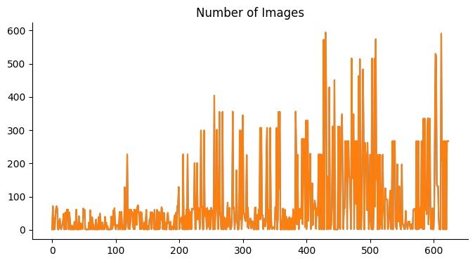

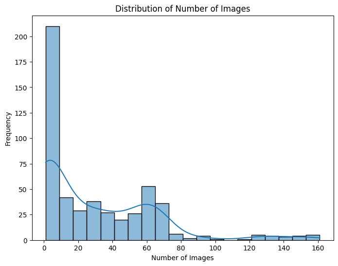

```python
import opendatasets as od
import pandas as pd
import numpy as np
import matplotlib.pyplot as plt
import seaborn as sns
from matplotlib import pyplot as plt
!pip install kaggle
! mkdir ~/.kaggle
!cp /content/drive/MyDrive/kaggle/kaggle.json ~/.kaggle/kaggle.json
!chmod 600 ~/.kaggle/kaggle.json
! pip install opendatasets
od.download("https://www.kaggle.com/datasets/nahin333/tcgaluad/data")
# Import necessary libraries

data = pd.read_csv("/content/tcgaluad/TCGA-LUAD/manifest-1Rd7jPNd5199284876140322680/metadata.csv")
data.size
print(data.shape)

data.info()
data.head(5)
data.describe()
# @title Number of Images

data['Number of Images'].plot(kind='line', figsize=(8, 4), title='Number of Images')
plt.gca().spines[['top', 'right']].set_visible(False)

# @title Number of Images

# Assuming you want to create a DataFrame with the 'Number of Images' column
df_number_of_images = pd.DataFrame({'Number of Images': data['Number of Images']})

# Now you can use df_number_of_images for further analysis or visualization

df_number_of_images['Number of Images'].plot(kind='line', figsize=(8, 4), title='Number of Images')
plt.gca().spines[['top', 'right']].set_visible(False)


# Check for missing values
missing_values = data.isnull().sum()
print("Missing values:\n", missing_values)


# Handle missing values (e.g., fill with mean, median, or drop rows/columns)
# Example: Fill missing values in 'Number of Images' with the mean
data['Number of Images'].fillna(data['Number of Images'].mean(), inplace=True)

# Check for duplicate rows
duplicate_rows = data.duplicated().sum()
print("Duplicate rows:", duplicate_rows)


# Remove duplicate rows if necessary
data.drop_duplicates(inplace=True)

# Check for inconsistent data types
print("Data types:\n", data.dtypes)

# Convert data types if necessary
# Example: Convert 'Number of Images' to integer
# data['Number of Images'] = data['Number of Images'].astype(int)

# Identify and handle outliers (e.g., using IQR or z-score)
# Example: Remove outliers in 'Number of Images' using IQR
Q1 = data['Number of Images'].quantile(0.25)
Q3 = data['Number of Images'].quantile(0.75)
IQR = Q3 - Q1
lower_bound = Q1 - 1.5 * IQR
upper_bound = Q3 + 1.5 * IQR
data = data[(data['Number of Images'] >= lower_bound) & (data['Number of Images'] <= upper_bound)]


# Verify the data cleaning process
print("Data after cleaning:\n", data.head())
print("Missing values after cleaning:\n", data.isnull().sum())
print("Duplicate rows after cleaning:", data.duplicated().sum())


# Data Distribution Analysis
# Let's analyze the distribution of 'Number of Images' using a histogram.
plt.figure(figsize=(8, 6))
sns.histplot(data['Number of Images'], bins=20, kde=True)
plt.title('Distribution of Number of Images')
plt.xlabel('Number of Images')
plt.ylabel('Frequency')
plt.show()

# Box Plots for Outlier Detection and Distribution
# Box plots can help identify outliers and visualize the distribution of a numerical feature across different categories.
if 'Patient Gender' in data.columns:
  plt.figure(figsize=(8, 6))
  sns.boxplot(x='Patient Gender', y='Number of Images', data=data)  # Replace 'Patient Gender' and 'Number of Images' with your desired columns
  plt.title('Distribution of Number of Images across Patient Gender')
  plt.xlabel('Patient Gender')
  plt.ylabel('Number of Images')
  plt.show()
```

```python
data.columns
```

```
Index(['Series UID', 'Collection', '3rd Party Analysis',
       'Data Description URI', 'Subject ID', 'Study UID', 'Study Description',
       'Study Date', 'Series Description', 'Manufacturer', 'Modality',
       'SOP Class Name', 'SOP Class UID', 'Number of Images', 'File Size',
       'File Location', 'Download Timestamp'],
      dtype='object')
```

[figure not shown]

```python
# Check if the column 'Patient Gender' exists in the DataFrame
if 'SOP Class Name' in data.columns:
  plt.figure(figsize=(4, 8))
  sns.countplot(x='Study Description', data=data)
  plt.title('Distribution of SOP Class Name')
  plt.xlabel('SOP Class Name')
  plt.ylabel('Count')
  plt.show()
else:
  print("Column 'SOP Class Name' not found in the DataFrame.")
```

[figure not shown]

```python
# Relationship between Features
# Scatter plots can help visualize the relationship between two numerical features.
plt.figure(figsize=(8, 6))
sns.scatterplot(x='Number of Images', y='Modality', data=data)  # Replace 'some_other_numerical_column' with an appropriate column name
plt.title('Relationship between Number of Images and Collection')
plt.xlabel('Number of Images')
plt.ylabel('Modality')
plt.show()
```

** Finding Correlation with a Heatmap**

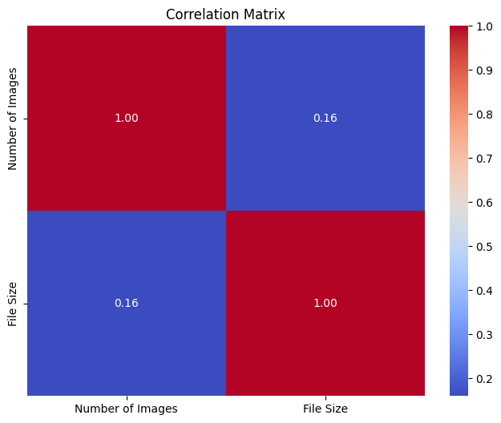

```
Numerical Data:
     Number of Images  File Size
0                  1     515.28
2                  1     515.73
4                  1     515.28
9                  1     515.71
10                 1     515.73

Correlation Matrix:
                   Number of Images  File Size
Number of Images          1.000000   0.160063
File Size                 0.160063   1.000000
```

```python
import pandas as pd
import matplotlib.pyplot as plt
import seaborn as sns
import numpy as np

# Assuming 'data' is your DataFrame

# 1. Select and Convert 'File Size'
numerical_data = data[['Number of Images', 'File Size']]

# --- Customize this part based on your 'File Size' format ---
# Example: If values are like "1234KB", use:
numerical_data['File Size'] = pd.to_numeric(numerical_data['File Size'].str.replace('KB', '').str.strip(), errors='coerce')

# Example: If values are like "1.23MB", use:
# numerical_data['File Size'] = pd.to_numeric(numerical_data['File Size'].str.replace('MB', '').str.strip(), errors='coerce') * 1024  # Convert to KB

# Example: If you have a mix of units, you'll need more complex logic
# ------------------------------------------------------------

# 2. Handle Missing Values
numerical_data = numerical_data.dropna()

# 3. Calculate Correlation
correlation_matrix = numerical_data.corr()

# 4. Create Heatmap
plt.figure(figsize=(8, 6))
sns.heatmap(correlation_matrix, annot=True, cmap='coolwarm', fmt=".2f")
plt.title('Correlation Matrix')
plt.show()

# --- Debugging ---
# Print statements to check data and correlation:
print("Numerical Data:\n", numerical_data.head())
print("\nCorrelation Matrix:\n", correlation_matrix)
```

**Scatter Plot for 'Number of Images' vs. 'File Size':**

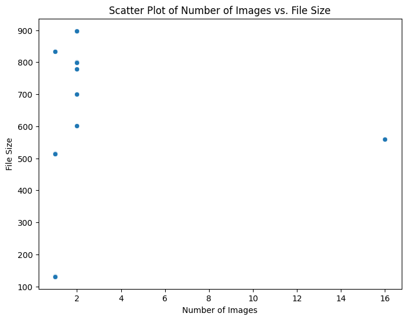

```python
# Assuming 'numerical_data' is your DataFrame with 'Number of Images' and 'File Size'

plt.figure(figsize=(8, 6))
sns.scatterplot(x='Number of Images', y='File Size', data=numerical_data)
plt.title('Scatter Plot of Number of Images vs. File Size')
plt.xlabel('Number of Images')
plt.ylabel('File Size')
plt.show()
```

**Exploring Correlation with Other Metadata (e.g., 'Modality'):**

```
Modality
CT    29.427984
NM     1.000000
PT    55.869565
Name: Number of Images, dtype: float64
```

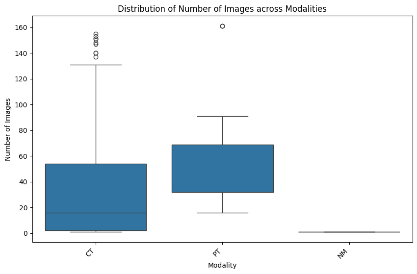

```python
# Assuming 'data' is your original DataFrame
modality_correlation = data.groupby('Modality')['Number of Images'].mean()
print(modality_correlation)

# Or, for a visual representation:
plt.figure(figsize=(10, 6))
sns.boxplot(x='Modality', y='Number of Images', data=data)
plt.title('Distribution of Number of Images across Modalities')
plt.xticks(rotation=45, ha='right')  # Rotate x-axis labels for better readability
plt.show()
```

**Feature Engineering:**

```python
numerical_data['File Size per Image'] = numerical_data['File Size'] / numerical_data['Number of Images']
print(numerical_data.head())
```

```
    Number of Images  File Size  File Size per Image
0                  1     515.28               515.28
2                  1     515.73               515.73
4                  1     515.28               515.28
9                  1     515.71               515.71
10                 1     515.73               515.73
```

**Applying Machine Learning Models** let's craft the code to predict 'File Size' using a Linear Regression model, based on my suggestion.

```python
from sklearn.model_selection import train_test_split
from sklearn.linear_model import LinearRegression
from sklearn.metrics import mean_squared_error

# Assuming 'numerical_data' is your DataFrame with 'Number of Images', 'File Size', etc.

# 1. Prepare your data
X = numerical_data[['Number of Images']]  # Features (you can add more features here)
y = numerical_data['File Size']  # Target variable

# 2. Split data into training and testing sets
X_train, X_test, y_train, y_test = train_test_split(X, y, test_size=0.2, random_state=42)

# 3. Create and train the model
model = LinearRegression()
model.fit(X_train, y_train)

# 4. Make predictions
y_pred = model.predict(X_test)

# 5. Evaluate the model
mse = mean_squared_error(y_test, y_pred)
print(f"Mean Squared Error: {mse}")

# (Optional) Print other evaluation metrics like R-squared
from sklearn.metrics import r2_score
r2 = r2_score(y_test, y_pred)
print(f"R-squared: {r2}")
```

```
Mean Squared Error: 19536.635136206027
R-squared: 0.01085245903104115
```

```
F1-score: 1.0
Confusion Matrix:
 [[22  0]
 [ 0  2]]
Classification Report:
               precision    recall  f1-score   support

           0       1.00      1.00      1.00        22
           1       1.00      1.00      1.00         2

    accuracy                           1.00        24
   macro avg       1.00      1.00      1.00        24
weighted avg       1.00      1.00      1.00        24
```

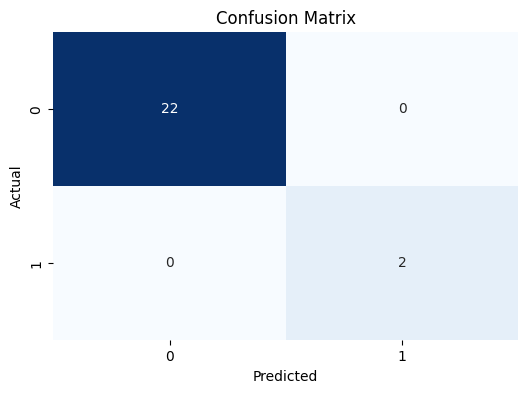

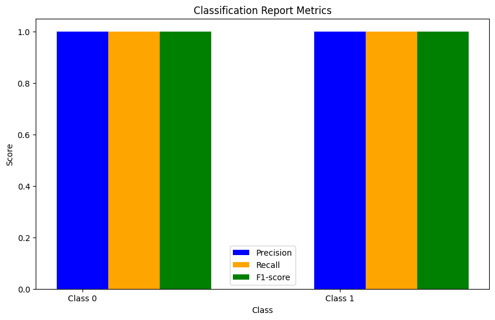

```python
import matplotlib.pyplot as plt
import seaborn as sns
from sklearn.metrics import f1_score, confusion_matrix, classification_report

# Assuming you have y_test and y_pred from your model (as in your provided code)

# Convert regression predictions to binary classification (e.g., above/below a threshold)
threshold = y_train.mean()  # You can adjust the threshold based on your problem
y_pred_binary = [1 if pred > threshold else 0 for pred in y_pred]
y_test_binary = [1 if val > threshold else 0 for val in y_test]

# Calculate F1-score
f1 = f1_score(y_test_binary, y_pred_binary)
print(f"F1-score: {f1}")

# Calculate Confusion Matrix
cm = confusion_matrix(y_test_binary, y_pred_binary)
print("Confusion Matrix:\n", cm)

# Generate a classification report (precision, recall, F1-score, support)
report = classification_report(y_test_binary, y_pred_binary)
print("Classification Report:\n", report)

# Plot the confusion matrix as a heatmap
plt.figure(figsize=(6, 4))
sns.heatmap(cm, annot=True, fmt="d", cmap="Blues", cbar=False)
plt.xlabel("Predicted")
plt.ylabel("Actual")
plt.title("Confusion Matrix")
plt.show()

# Create a bar chart for the classification report
report_data = classification_report(y_test_binary, y_pred_binary, output_dict=True)
precision = [report_data['0']['precision'], report_data['1']['precision']]
recall = [report_data['0']['recall'], report_data['1']['recall']]
f1_score_values = [report_data['0']['f1-score'], report_data['1']['f1-score']]

x = ['Class 0', 'Class 1']

plt.figure(figsize=(10, 6))
plt.bar(x, precision, label='Precision', width=0.2, color='blue')
plt.bar([i + 0.2 for i, _ in enumerate(x)], recall, label='Recall', width=0.2, color='orange')
plt.bar([i + 0.4 for i, _ in enumerate(x)], f1_score_values, label='F1-score', width=0.2, color='green')

plt.xlabel("Class")
plt.ylabel("Score")
plt.title("Classification Report Metrics")
plt.legend()
plt.show()

# You can customize the colors, labels, and figure size to make it look better.
```

```python
from sklearn.svm import SVR  # Import SVR for regression
from sklearn.model_selection import train_test_split
from sklearn.metrics import mean_squared_error, r2_score  # Import regression metrics

# Assuming you have X and y defined for regression:
# X = numerical_data[['Number of Images']]
# y = numerical_data['File Size']  # Target variable (continuous)

# Split data into training and testing sets
X_train, X_test, y_train, y_test = train_test_split(X, y, test_size=0.2, random_state=42)

# Create and train an SVR model
svm_model = SVR(kernel='linear')  # You can experiment with different kernels
svm_model.fit(X_train, y_train)

# Make predictions on the test set
y_pred = svm_model.predict(X_test)

# Evaluate the model using regression metrics
mse = mean_squared_error(y_test, y_pred)
rmse = np.sqrt(mse)  # Calculate RMSE
r2 = r2_score(y_test, y_pred)

print(f"Mean Squared Error: {mse}")
print(f"Root Mean Squared Error: {rmse}")
print(f"R-squared: {r2}")
```

```
Mean Squared Error: 19688.27061203704
Root Mean Squared Error: 140.31489804021894
R-squared: 0.003175095094201441
```

```python
from sklearn.model_selection import GridSearchCV
from sklearn.model_selection import train_test_split
from sklearn.metrics import mean_squared_error

# Assuming 'numerical_data' is your DataFrame with 'Number of Images', 'File Size'
X = numerical_data[['Number of Images']]
y = numerical_data['File Size']

# Split data into training and testing sets
X_train, X_test, y_train, y_test = train_test_split(X, y, test_size=0.2, random_state=42)

# Define the parameter grid to search
param_grid = {
    'kernel': ['linear', 'rbf', 'poly'],
    'C': [0.1, 1, 10],
    'epsilon': [0.01, 0.1, 1],
    'gamma': ['scale', 'auto']  # Add gamma for 'rbf' and 'poly' kernels
}

# Create a GridSearchCV object
grid_search = GridSearchCV(SVR(), param_grid, scoring='neg_mean_squared_error', cv=5)

# Fit the grid search to the training data
grid_search.fit(X_train, y_train)

# Get the best model and its parameters
best_model = grid_search.best_estimator_
best_params = grid_search.best_params_

print("Best Parameters:", best_params)

# Evaluate the best model on the test set
y_pred = best_model.predict(X_test)
mse = mean_squared_error(y_test, y_pred)
print(f"Mean Squared Error (Best Model): {mse}")
```

```
Best Parameters: {'C': 10, 'epsilon': 0.01, 'gamma': 'auto', 'kernel': 'rbf'}
Mean Squared Error (Best Model): 16413.464388664866
```

```python
from sklearn.metrics import mean_squared_error, r2_score

# ... (Your code for hyperparameter tuning and getting the best SVR model) ...

# Evaluate the best model on the test set
y_pred = best_model.predict(X_test)

# Regression metrics
mse = mean_squared_error(y_test, y_pred)
rmse = np.sqrt(mse)
r2 = r2_score(y_test, y_pred)

print(f"Mean Squared Error (Best Model): {mse}")
print(f"Root Mean Squared Error (Best Model): {rmse}")
print(f"R-squared (Best Model): {r2}")

# Adapt classification metrics to regression
# 1. Define a threshold to convert continuous predictions to binary classes
threshold = y_train.mean()  # You can adjust this threshold
y_pred_binary = [1 if pred > threshold else 0 for pred in y_pred]
y_test_binary = [1 if val > threshold else 0 for val in y_test]

# 2. Calculate confusion matrix, F1-score, and precision
from sklearn.metrics import confusion_matrix, f1_score, precision_score

cm = confusion_matrix(y_test_binary, y_pred_binary)
f1 = f1_score(y_test_binary, y_pred_binary)
precision = precision_score(y_test_binary, y_pred_binary)

print("\nConfusion Matrix (Best Model):\n", cm)
print(f"F1-score (Best Model): {f1}")
print(f"Precision (Best Model): {precision}")
```

```
Mean Squared Error (Best Model): 16413.464388664866
Root Mean Squared Error (Best Model): 128.11504356891453
R-squared (Best Model): 0.16897982556159385

Confusion Matrix (Best Model):
 [[22  0]
 [ 0  2]]
F1-score (Best Model): 1.0
Precision (Best Model): 1.0
```

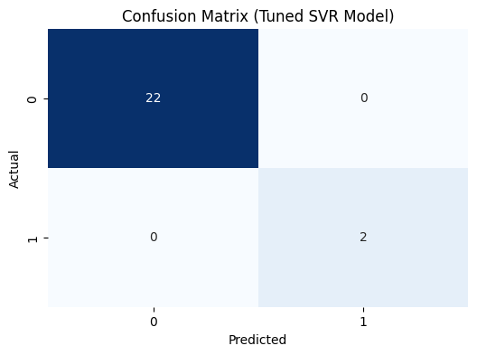

```python
# Plot the confusion matrix as a heatmap
plt.figure(figsize=(6, 4))
sns.heatmap(cm, annot=True, fmt="d", cmap="Blues", cbar=False)
plt.xlabel("Predicted")
plt.ylabel("Actual")
plt.title("Confusion Matrix (Tuned SVR Model)")
plt.show()
```

```
Best Parameters: {'C': 10, 'epsilon': 0.01, 'gamma': 'auto', 'kernel': 'rbf'}
Mean Squared Error (Best Model): 16846.414704313403
Root Mean Squared Error (Best Model): 129.79373907979308
R-squared (Best Model): 0.14705938035187427

Confusion Matrix (Best Model):
 [[22  0]
 [ 0  2]]
F1-score (Best Model): 1.0
Precision (Best Model): 1.0
```

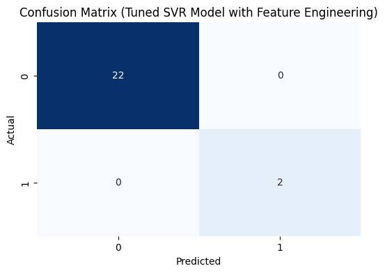

```python
# ... (Previous code for loading and preparing data) ...

# Feature Engineering (example - logarithmic transformation)
numerical_data['Log_Number_of_Images'] = np.log1p(numerical_data['Number of Images'])

# Prepare data with the new feature
X = numerical_data[['Number of Images', 'Log_Number_of_Images']]
y = numerical_data['File Size']

# Split data into training and testing sets
X_train, X_test, y_train, y_test = train_test_split(X, y, test_size=0.2, random_state=42)

# Define the parameter grid (potentially adjusted after feature engineering)
param_grid = {
    'kernel': ['linear', 'rbf'],
    'C': [0.1, 1, 10],
    'epsilon': [0.01, 0.1, 1],
    'gamma': ['scale', 'auto']
}

# Create and fit GridSearchCV
grid_search = GridSearchCV(SVR(), param_grid, scoring='neg_mean_squared_error', cv=5)
grid_search.fit(X_train, y_train)

# Get the best model and parameters
best_model = grid_search.best_estimator_
best_params = grid_search.best_params_
print("Best Parameters:", best_params)

# Evaluate the best model
y_pred = best_model.predict(X_test)

# Regression metrics
mse = mean_squared_error(y_test, y_pred)
rmse = np.sqrt(mse)
r2 = r2_score(y_test, y_pred)
print(f"Mean Squared Error (Best Model): {mse}")
print(f"Root Mean Squared Error (Best Model): {rmse}")
print(f"R-squared (Best Model): {r2}")

# Adapt classification metrics
threshold = y_train.mean()
y_pred_binary = [1 if pred > threshold else 0 for pred in y_pred]
y_test_binary = [1 if val > threshold else 0 for val in y_test]

# Calculate and print results
cm = confusion_matrix(y_test_binary, y_pred_binary)
f1 = f1_score(y_test_binary, y_pred_binary)
precision = precision_score(y_test_binary, y_pred_binary)

print("\nConfusion Matrix (Best Model):\n", cm)
print(f"F1-score (Best Model): {f1}")
print(f"Precision (Best Model): {precision}")

# Plot the confusion matrix as a heatmap
plt.figure(figsize=(6, 4))
sns.heatmap(cm, annot=True, fmt="d", cmap="Blues", cbar=False)
plt.xlabel("Predicted")
plt.ylabel("Actual")
plt.title("Confusion Matrix (Tuned SVR Model with Feature Engineering)")
plt.show()
```

**Train and evaluate other regression models (Linear Regression, Decision Tree Regression)**

Train and evaluate other regression models (Linear Regression, Decision Tree Regression, etc.) using the same features and target variable. Calculate the same regression and adapted classification metrics for each model. Compare the performance of all models based on these metrics to identify the most suitable algorithm for your dataset.

```
               Model           MSE        RMSE        R2  F1-score  Precision
0                SVR  16846.414704  129.793739  0.147059       1.0        1.0
1  Linear Regression  12411.496409  111.406896  0.371601       1.0        1.0
2      Decision Tree  12411.496409  111.406896  0.371601       1.0        1.0
3      Random Forest  12428.149566  111.481611  0.370758       1.0        1.0
```

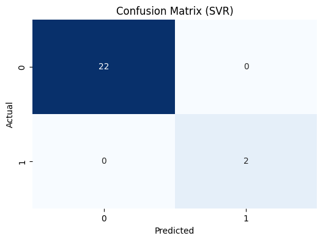

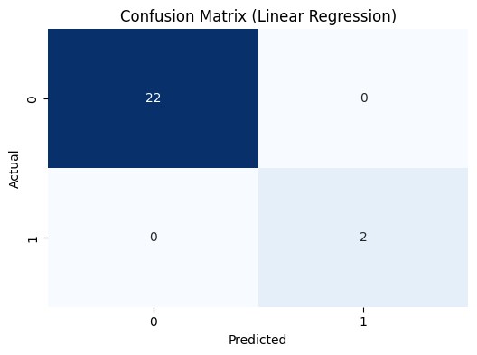

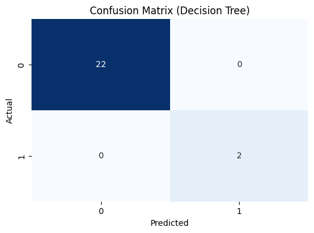

```python
from sklearn.linear_model import LinearRegression
from sklearn.tree import DecisionTreeRegressor
from sklearn.ensemble import RandomForestRegressor
from sklearn.metrics import mean_squared_error, r2_score, f1_score, confusion_matrix, precision_score



# ... (Previous code for loading and preparing data, including feature engineering) ...


# Define models to compare
models = {
    "SVR": SVR(**best_params),  # Use the best parameters found in Step 2
    "Linear Regression": LinearRegression(),
    "Decision Tree": DecisionTreeRegressor(),
    "Random Forest": RandomForestRegressor(),
}

# Train and evaluate each model
results = []
for model_name, model in models.items():
    # Train the model
    model.fit(X_train, y_train)

    # Make predictions
    y_pred = model.predict(X_test)

    # Calculate regression metrics
    mse = mean_squared_error(y_test, y_pred)
    rmse = np.sqrt(mse)
    r2 = r2_score(y_test, y_pred)

    # Adapt classification metrics (using threshold from Step 2)
    y_pred_binary = [1 if pred > threshold else 0 for pred in y_pred]
    cm = confusion_matrix(y_test_binary, y_pred_binary)
    f1 = f1_score(y_test_binary, y_pred_binary)
    precision = precision_score(y_test_binary, y_pred_binary)

    # Store results
    results.append([model_name, mse, rmse, r2, f1, precision])

# Create a DataFrame to display results
results_df = pd.DataFrame(results, columns=["Model", "MSE", "RMSE", "R2", "F1-score", "Precision"])
print(results_df)


# Optional: Visualize confusion matrices for each model
for model_name, model in models.items():
    model.fit(X_train, y_train)
    y_pred = model.predict(X_test)
    y_pred_binary = [1 if pred > threshold else 0 for pred in y_pred]
    cm = confusion_matrix(y_test_binary, y_pred_binary)

    plt.figure(figsize=(6, 4))
    sns.heatmap(cm, annot=True, fmt="d", cmap="Blues", cbar=False)
    plt.xlabel("Predicted")
    plt.ylabel("Actual")
    plt.title(f"Confusion Matrix ({model_name})")
    plt.show()
```

[output not shown]

**Visualize Results** Create scatter plots, residual plots, and potentially feature importance plots (for tree-based models) to gain insights into the model's behavior and relationships between variables.